# Analysis of echo parameters and others

Filimonova Irina

2024-02-10

# Correlation analysis

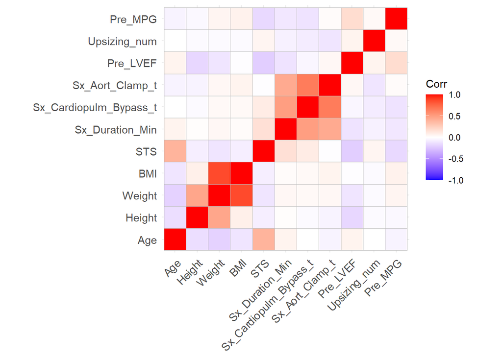

# Additional graphs for EDA

## Bar plot of pattern over the years of replacement of aortic valve

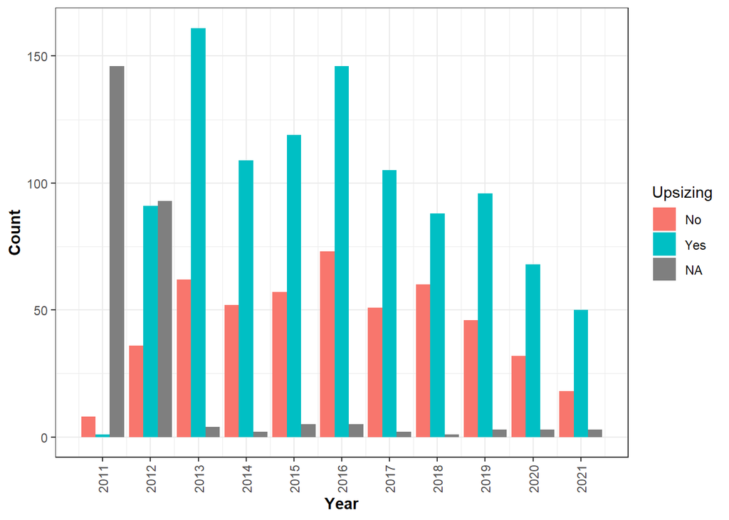

## + percent of operations

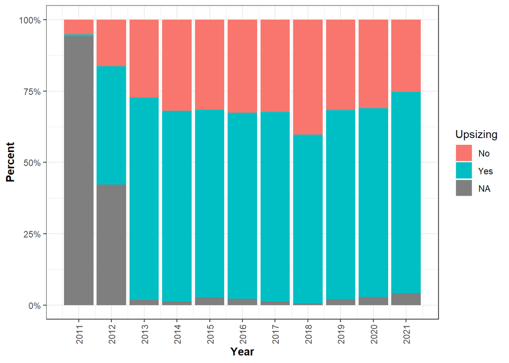

## Box plot of STS from the outcome depending on the type of prosthetics.

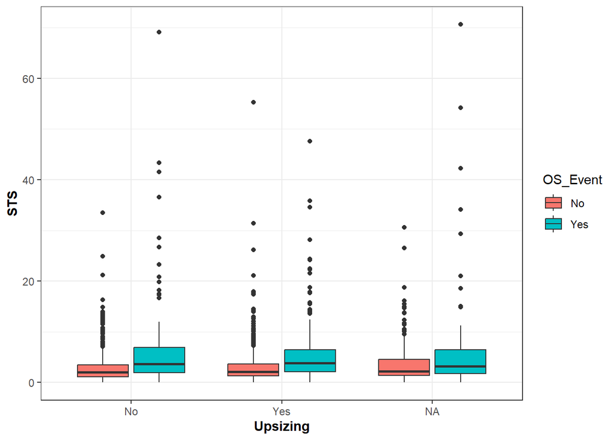

## Box plot of MPG from the outcome depending on the type of prosthetics.

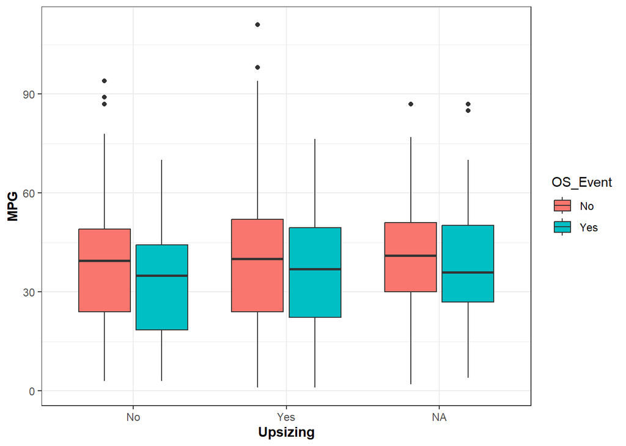

## Сomorbidities

```
##  Upsizing    Congestive heart failure Pulmonary hypertension Hypertension
##  No  : 495   0:  67                   0   :1308              0   :  66
##  Yes :1034   1:1729                   1   : 418              1   :1716
##  NA's: 267                            NA's:  70              NA's:  14
##  Coronary artery disease Atrial fibrillation Peripheral artery disease
##  0   :853                0:1767              0:1588
##  1   :871                1:  29              1: 208
##  NA's: 72
##  Endocarditis Renal Failure
##  0:1646       0   :1672
##  1: 150       1   :  53
##               NA's:  71
```

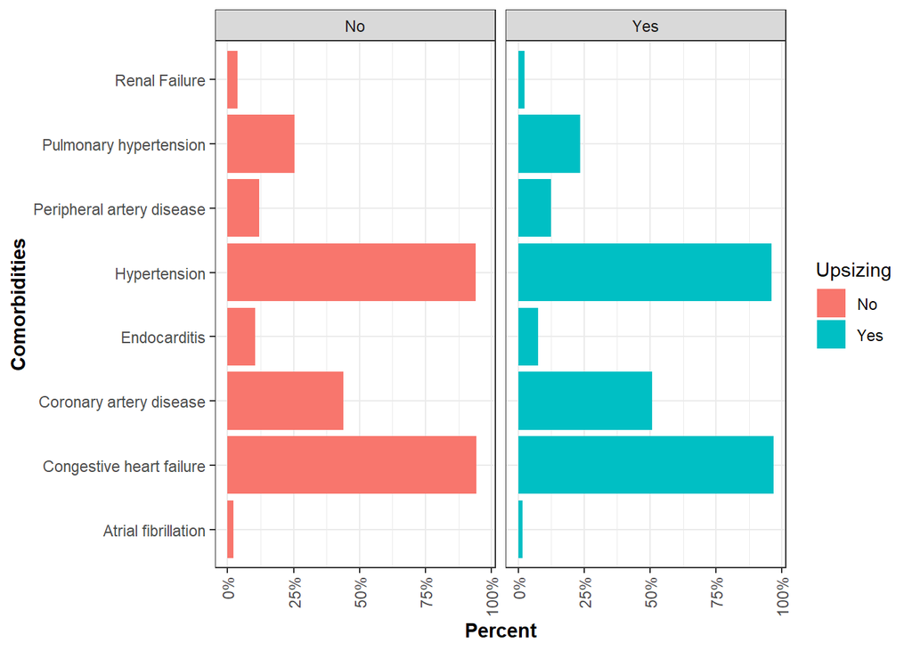

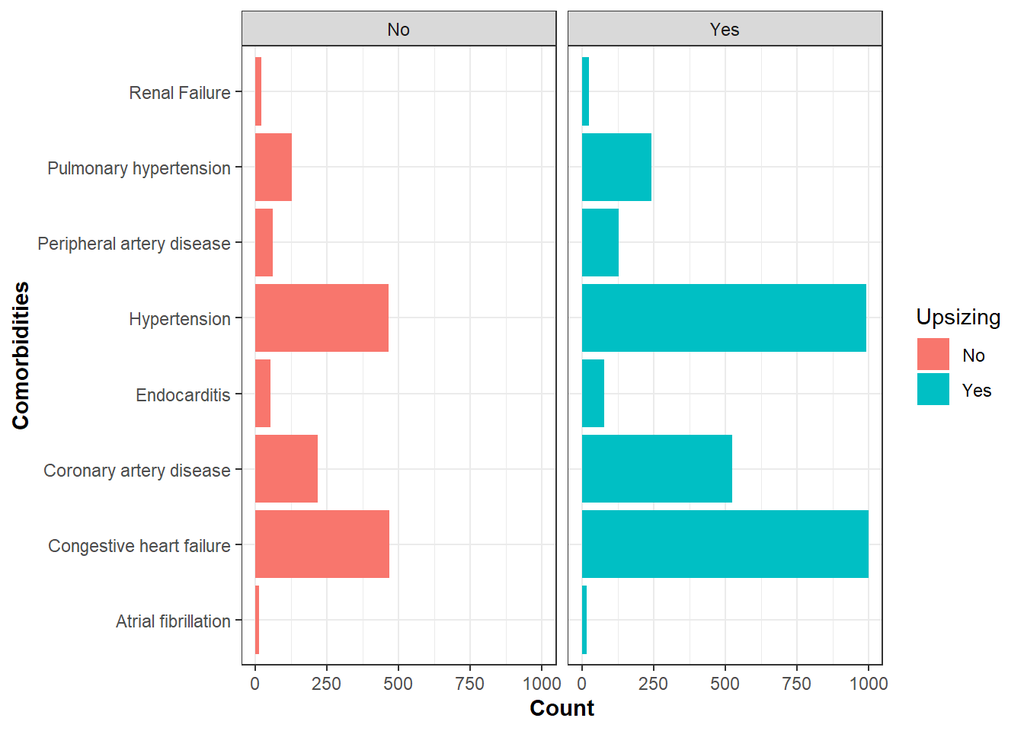

# Comparison of echocardiography parameters between groups with normal-sized and upsizing

## before surgery

| **Variable** | **Upsizing** **No**, N = 495<sup>1</sup> | **Upsizing** **Yes**, N = 1,034<sup>1</sup> | **p-value**<sup>2</sup> | **q-value**<sup>3</sup> |  |  |
| --- | --- | --- | --- | --- | --- | --- |
| LVEF, % |  |  |  |  | 0.061 | 0.6 |
| Mean (SD) | 54.4 (13.7) | 56.1 (14.1) |  |  |  |  |
| LVDd, cm |  |  | 0.053 | 0.6 |  |  |
| Mean (SD) | 6.1 (5.6) | 5.4 (1.0) |  |  |  |  |
| LVDs, cm |  |  | 0.059 | 0.6 |  |  |
| Mean (SD) | 3.9 (1.3) | 3.6 (1.1) |  |  |  |  |
| LVOT, cm |  |  | 0.8 | >0.9 |  |  |
| Mean (SD) | 2.5 (1.8) | 2.5 (2.2) |  |  |  |  |
| PAP, mmHg |  |  | 0.5 | >0.9 |  |  |
| Mean (SD) | 29.4 (12.7) | 28.7 (12.0) |  |  |  |  |
| IVSd, cm |  |  | >0.9 | >0.9 |  |  |
| Mean (SD) | 1.5 (0.4) | 1.5 (0.7) |  |  |  |  |
| IVSs, cm |  |  | 0.11 | 0.9 |  |  |
| Mean (SD) | 1.9 (0.4) | 1.8 (0.4) |  |  |  |  |
| MPG, mmHg |  |  | 0.2 | >0.9 |  |  |
| Mean (SD) | 36.7 (19.1) | 38.6 (19.8) |  |  |  |  |
| Vmax, m/sec |  |  | 0.067 | 0.6 |  |  |
| Mean (SD) | 3.7 (1.1) | 3.9 (2.6) |  |  |  |  |
| Aortic valve area, cm2 |  |  | 0.2 | >0.9 |  |  |
| Mean (SD) | 1.1 (0.7) | 1.0 (0.6) |  |  |  |  |
| Aortic insufficiency |  |  | 0.4 | >0.9 |  |  |
| 0 | 50 (18.1%) | 132 (23.2%) |  |  |  |  |
| 1 | 105 (37.9%) | 200 (35.1%) |  |  |  |  |
| 2 | 65 (23.5%) | 133 (23.4%) |  |  |  |  |
| 3-4 | 57 (20.6%) | 104 (18.3%) |  |  |  |  |
| Pulmonary Hypertension | 73 (39.9%) | 126 (34.4%) | 0.2 | >0.9 |  |  |

<sup>1</sup> n (%)  
<sup>2</sup> Welch Two Sample t-test; Pearson’s Chi-squared test  
<sup>3</sup> Holm correction for multiple testing

We use the Holm’s method for controlling FWER.

There were no statistically significant differences found between the group with upsizing and the group with a normal-sized prosthesis ( Welch Two Sample t-test, p adj>0.05).

## before surgery - follow-up

| **Variable** | **Upsizing** **No**, N = 495 | **Upsizing** **Yes**, N = 1,034 | **p-value**<sup>1</sup> | **q-value**<sup>2</sup> |  |  |
| --- | --- | --- | --- | --- | --- | --- |
| Pre_LVEF-FUEcho_EF |  |  |  |  | 0.8 | >0.9 |
| Mean (SD) | -0.1 (13.4) | -0.5 (14.6) |  |  |  |  |
| Median (IQR) | 0.0 (-10.0, 8.0) | 0.0 (-8.0, 8.0) |  |  |  |  |
| Range | -33.0, 38.0 | -58.3, 63.4 |  |  |  |  |
| Unknown | 358 | 697 |  |  |  |  |
| Pre_LVDd-FUEcho_LVDd |  |  | 0.3 | >0.9 |  |  |
| Mean (SD) | 0.5 (1.2) | 0.4 (0.9) |  |  |  |  |
| Median (IQR) | 0.4 (-0.1, 1.1) | 0.4 (-0.2, 1.0) |  |  |  |  |
| Range | -2.2, 3.5 | -3.7, 2.7 |  |  |  |  |
| Unknown | 432 | 907 |  |  |  |  |
| Pre_LVDs-FUEcho_LVDs |  |  | 0.3 | >0.9 |  |  |
| Mean (SD) | 0.4 (1.0) | 0.1 (0.9) |  |  |  |  |
| Median (IQR) | 0.1 (-0.1, 1.1) | 0.0 (-0.5, 0.7) |  |  |  |  |
| Range | -1.0, 2.5 | -2.1, 1.9 |  |  |  |  |
| Unknown | 479 | 995 |  |  |  |  |
| Pre_LVOT-FUEcho_LVOT |  |  | 0.3 | >0.9 |  |  |
| Mean (SD) | 0.2 (0.3) | -0.7 (4.7) |  |  |  |  |
| Median (IQR) | 0.2 (-0.1, 0.4) | 0.0 (-0.2, 0.2) |  |  |  |  |
| Range | -0.1, 0.6 | -26.8, 0.8 |  |  |  |  |
| Unknown | 489 | 1,001 |  |  |  |  |
| Pre_PAP-FUEcho_PAP |  |  | 0.6 | >0.9 |  |  |
| Mean (SD) | -1.0 (13.3) | -2.3 (17.2) |  |  |  |  |
| Median (IQR) | -2.0 (-8.0, 8.3) | -2.0 (-10.0, 7.8) |  |  |  |  |
| Range | -30.0, 28.0 | -57.0, 44.0 |  |  |  |  |
| Unknown | 449 | 956 |  |  |  |  |
| Pre_IVSd-FUEcho_IVSd |  |  | 0.3 | >0.9 |  |  |
| Mean (SD) | -0.2 (2.5) | 0.2 (0.3) |  |  |  |  |
| Median (IQR) | 0.1 (-0.1, 0.4) | 0.2 (0.0, 0.4) |  |  |  |  |
| Range | -19.5, 0.8 | -0.7, 1.1 |  |  |  |  |
| Unknown | 434 | 908 |  |  |  |  |
| Pre_MAVG-FUEcho_MPG |  |  | 0.4 | >0.9 |  |  |
| Mean (SD) | 24.4 (21.1) | 27.2 (20.6) |  |  |  |  |
| Median (IQR) | 24.0 (7.3, 37.8) | 29.0 (11.0, 41.5) |  |  |  |  |
| Range | -13.0, 80.0 | -15.0, 94.0 |  |  |  |  |
| Unknown | 433 | 871 |  |  |  |  |
| Pre_Vmax-FUEcho_Vmax |  |  | 0.3 | >0.9 |  |  |
| Mean (SD) | 1.3 (1.1) | 1.5 (1.1) |  |  |  |  |
| Median (IQR) | 1.5 (0.6, 2.2) | 1.6 (0.9, 2.3) |  |  |  |  |
| Range | -1.2, 3.5 | -1.3, 3.9 |  |  |  |  |
| Unknown | 422 | 854 |  |  |  |  |
| Pre_Aort_Valve_Area-FUEcho_AOF |  |  | 0.4 | >0.9 |  |  |
| Mean (SD) | -1.3 (1.1) | -1.0 (1.1) |  |  |  |  |
| Median (IQR) | -1.2 (-1.4, -0.9) | -1.0 (-1.9, -0.4) |  |  |  |  |
| Range | -4.0, 0.2 | -2.8, 2.6 |  |  |  |  |
| Unknown | 483 | 993 |  |  |  |  |

<sup>1</sup> Welch Two Sample t-test  
<sup>2</sup> Holm correction for multiple testing

# Comparison of operation characteristics between groups with normal-sized and upsizing

```
## # A tibble: 2 × 5
##   Upsizing variable            n  mean    sd
##   <fct>    <fct>           <dbl> <dbl> <dbl>
## 1 No       Sx_Duration_Min   495  202.  71.9
## 2 Yes      Sx_Duration_Min  1034  194.  76.4
```

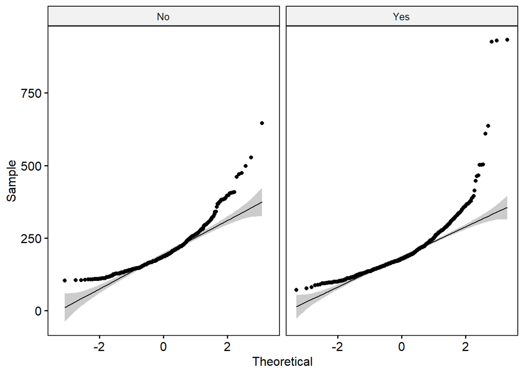

```
## # A tibble: 1 × 12
##   .y.   group1 group2    n1    n2 statistic    df      p y.position groups  xmin
##   <chr> <chr>  <chr>  <int> <int>     <dbl> <dbl>  <dbl>      <dbl> <name> <dbl>
## 1 Sx_D… No     Yes      495  1034      2.07 1029. 0.0388       967. <chr>      1
## # ℹ 1 more variable: xmax <dbl>
```

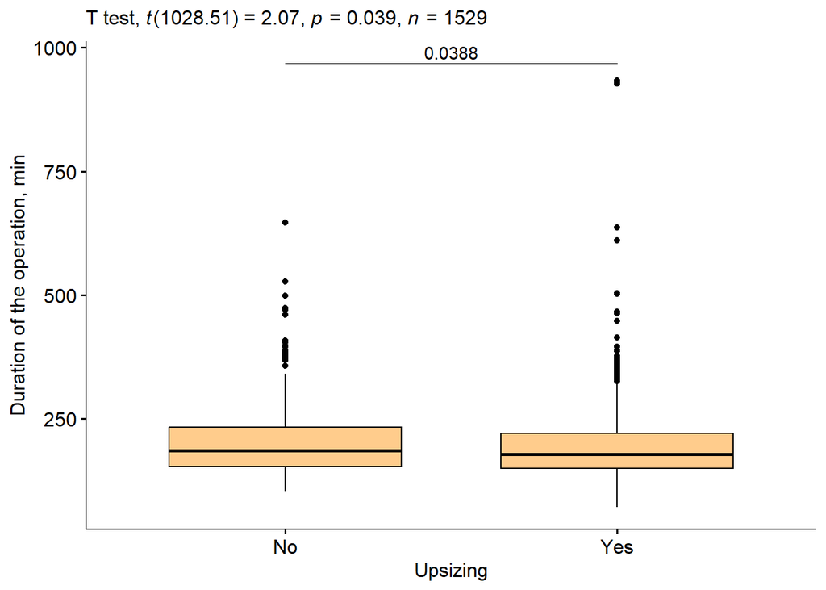

The difference in mean Duration of the operation between the standard size group and the upsizing group 8.3 [0.4 ; 16.18] min. The difference is clinically insignificant.

```
## # A tibble: 2 × 5
##   Upsizing variable                   n  mean    sd
##   <fct>    <fct>                  <dbl> <dbl> <dbl>
## 1 No       Sx_Cardiopulm_Bypass_t   495  115.  46.8
## 2 Yes      Sx_Cardiopulm_Bypass_t  1034  107.  41.4
```

```
## # A tibble: 1 × 12
##   .y.        group1 group2    n1    n2 statistic    df       p y.position groups
##   <chr>      <chr>  <chr>  <int> <int>     <dbl> <dbl>   <dbl>      <dbl> <name>
## 1 Sx_Cardio… No     Yes      495  1034      3.19  874. 0.00148       356. <chr>
## # ℹ 2 more variables: xmin <dbl>, xmax <dbl>
```

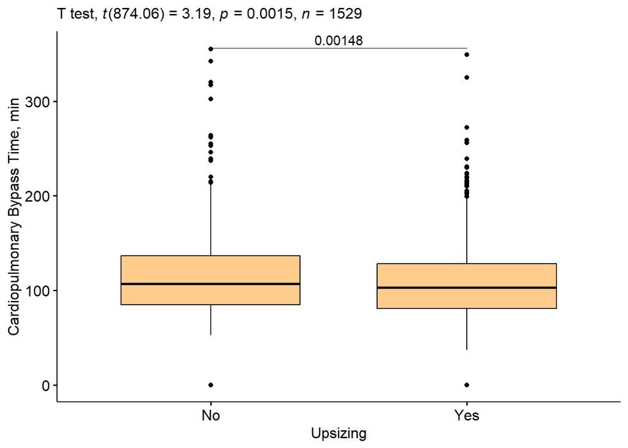

The difference in mean Cardiopulmonary Bypass Time between the standard size group and the upsizing group 7.9 [3 ; 12.71] min.

```
## # A tibble: 2 × 5
##   Upsizing variable            n  mean    sd
##   <fct>    <fct>           <dbl> <dbl> <dbl>
## 1 No       Sx_Aort_Clamp_t   495  76.0  29.8
## 2 Yes      Sx_Aort_Clamp_t  1034  68.8  24.6
```

```
## # A tibble: 1 × 12
##   .y.        group1 group2    n1    n2 statistic    df       p y.position groups
##   <chr>      <chr>  <chr>  <int> <int>     <dbl> <dbl>   <dbl>      <dbl> <name>
## 1 Sx_Aort_C… No     Yes      495  1034      4.63  827. 4.17e-6       259. <chr>
## # ℹ 2 more variables: xmin <dbl>, xmax <dbl>
```

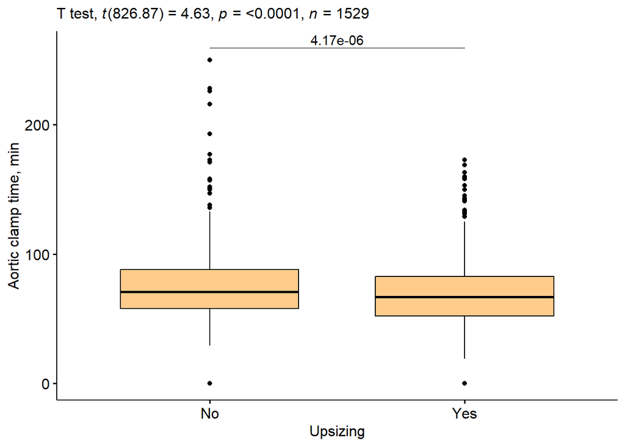

The difference in mean Aortic clamp time between the standard size group and the upsizing group 7.2 [4.1 ; 10.18] min.

## Summary table of temporal characteristics of the operation

| **Variable** | **Upsizing** **No**, N = 495 | **Upsizing** **Yes**, N = 1,034 | **p-value**<sup>1</sup> | **q-value**<sup>2</sup> |  |  |
| --- | --- | --- | --- | --- | --- | --- |
| Duration of the operation, min |  |  |  |  | 0.039 | 0.039 |
| Mean (SD) | 202.5 (71.9) | 194.2 (76.4) |  |  |  |  |
| Median (IQR) | 186.0 (153.0, 232.5) | 178.0 (150.0, 220.0) |  |  |  |  |
| Range | 104.0, 646.0 | 71.0, 933.0 |  |  |  |  |
| Duration of cardiopulmonary bypass, min |  |  | 0.001 | 0.003 |  |  |
| Mean (SD) | 114.6 (46.8) | 106.7 (41.4) |  |  |  |  |
| Median (IQR) | 107.0 (85.0, 136.5) | 103.0 (81.0, 128.0) |  |  |  |  |
| Range | 0.0, 355.0 | 0.0, 349.0 |  |  |  |  |
| Aortic clamping time, min |  |  | <0.001 | <0.001 |  |  |
| Mean (SD) | 76.0 (29.8) | 68.8 (24.6) |  |  |  |  |
| Median (IQR) | 71.0 (58.0, 88.0) | 67.0 (52.0, 82.8) |  |  |  |  |
| Range | 0.0, 250.0 | 0.0, 173.0 |  |  |  |  |

<sup>1</sup> Welch Two Sample t-test  
<sup>2</sup> Holm correction for multiple testing

# MPG (pre-post) vs Upsizing (linear regression)

**MPG post linear model**

| **Characteristic** | **Beta**<sup>1</sup> | **SE**<sup>2</sup> | **95% CI**<sup>2</sup> | **p-value** |
| --- | --- | --- | --- | --- |
| (Intercept) | 12*** | 0.288 | 12, 13 | <0.001 |
| Upsizing |  |  |  |  |
| No | — | — | — |  |
| Yes | -0.50 | 0.347 | -1.2, 0.18 | 0.15 |

R² = 0.002; Adjusted R² = 0.001; Sigma = 5.58; Statistic = 2.11; p-value = 0.15; df = 1; Log-likelihood = -3,767; AIC = 7,540; BIC = 7,555; Deviance = 37,283; Residual df = 1,199; No. Obs. = 1,201  
<sup>1</sup> *p<0.05; **p<0.01; ***p<0.001  
<sup>2</sup> SE = Standard Error, CI = Confidence Interval

**MPG post linear model adj**

| **Characteristic** | **Beta**<sup>1</sup> | **SE**<sup>2</sup> | **95% CI**<sup>2</sup> | **p-value** |
| --- | --- | --- | --- | --- |
| (Intercept) | 26*** | 2.52 | 21, 31 | <0.001 |
| Pre MPG | 0.03*** | 0.010 | 0.01, 0.05 | <0.001 |
| Upsizing |  |  |  |  |
| No | — | — | — |  |
| Yes | -1.7*** | 0.447 | -2.6, -0.87 | <0.001 |
| Prosthesis_Anat_Size | -0.60*** | 0.092 | -0.78, -0.41 | <0.001 |

R² = 0.093; Adjusted R² = 0.088; Sigma = 4.56; Statistic = 21.0; p-value = <0.001; df = 3; Log-likelihood = -1,818; AIC = 3,647; BIC = 3,669; Deviance = 12,802; Residual df = 616; No. Obs. = 620  
<sup>1</sup> *p<0.05; **p<0.01; ***p<0.001  
<sup>2</sup> SE = Standard Error, CI = Confidence Interval

```
##            `Pre MPG`             Upsizing Prosthesis_Anat_Size
##             1.029527             1.218866             1.248938
```

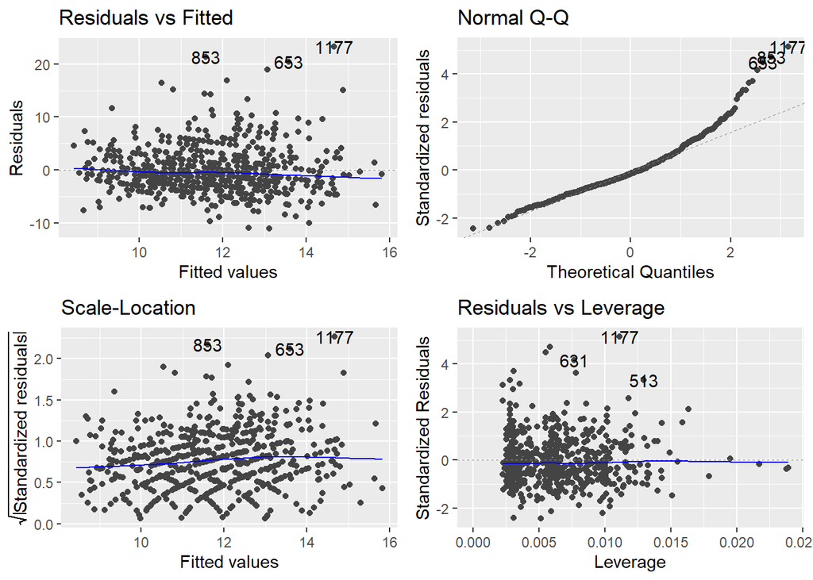

**Summary table for MPG (pre-post)**

|  | MPG (post) crude | MPG (post) adj. |
| --- | --- | --- |
| UpsizingYes | -0.5 [-1.2, 0.2] | -1.7 ***[-2.6, -0.9] |
| Pre MPG |  | 0.0 ***[0.0, 0.1] |
| Prosthesis_Anat_Size |  | -0.6 ***[-0.8, -0.4] |
| Num.Obs. | 1201 | 620 |

# EF (pre-post) linear model

**EF post linear model**

| **Characteristic** | **Beta**<sup>1</sup> | **SE**<sup>2</sup> | **95% CI**<sup>2</sup> | **p-value** |
| --- | --- | --- | --- | --- |
| (Intercept) | 54*** | 0.627 | 53, 55 | <0.001 |
| Upsizing |  |  |  |  |
| No | — | — | — |  |
| Yes | 2.8*** | 0.757 | 1.3, 4.3 | <0.001 |

R² = 0.011; Adjusted R² = 0.011; Sigma = 12.1; Statistic = 13.5; p-value = <0.001; df = 1; Log-likelihood = -4,616; AIC = 9,238; BIC = 9,253; Deviance = 171,656; Residual df = 1,179; No. Obs. = 1,181  
<sup>1</sup> *p<0.05; **p<0.01; ***p<0.001  
<sup>2</sup> SE = Standard Error, CI = Confidence Interval

**EF post linear model adj**

| **Characteristic** | **Beta**<sup>1</sup> | **SE**<sup>2</sup> | **95% CI**<sup>2</sup> | **p-value** |
| --- | --- | --- | --- | --- |
| (Intercept) | 48*** | 4.66 | 38, 57 | <0.001 |
| Pre_LVEF | 0.43*** | 0.024 | 0.38, 0.48 | <0.001 |
| Upsizing |  |  |  |  |
| No | — | — | — |  |
| Yes | 1.4 | 0.791 | -0.17, 2.9 | 0.080 |
| Prosthesis_Anat_Size | -0.71*** | 0.164 | -1.0, -0.38 | <0.001 |

R² = 0.286; Adjusted R² = 0.284; Sigma = 10.2; Statistic = 130; p-value = <0.001; df = 3; Log-likelihood = -3,665; AIC = 7,340; BIC = 7,364; Deviance = 102,283; Residual df = 975; No. Obs. = 979  
<sup>1</sup> *p<0.05; **p<0.01; ***p<0.001  
<sup>2</sup> SE = Standard Error, CI = Confidence Interval

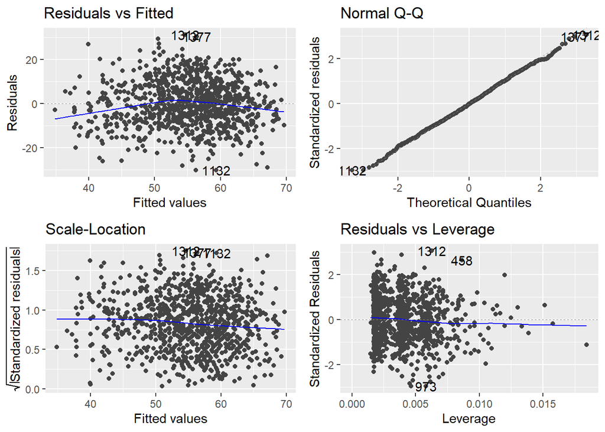

**Summary table for EF (pre-post)**

|  | EF (post) crude | EF (post) adj. |
| --- | --- | --- |
| UpsizingYes | 2.8 ***[1.3, 4.3] | 1.4 +[-0.2, 2.9] |
| Pre_LVEF |  | 0.4 ***[0.4, 0.5] |
| Prosthesis_Anat_Size |  | -0.7 ***[-1.0, -0.4] |
| Num.Obs. | 1181 | 979 |

# MPG (pre/follow-up) vs Upsizing

```
## [1] 0
```

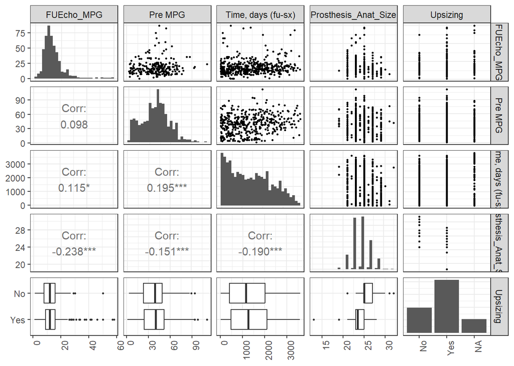

## Crude

**MPG follow-up linear model**

```
## Length  Class   Mode
##      0   NULL   NULL
```

| **Characteristic** | **Beta**<sup>1</sup> | **SE**<sup>2</sup> | **95% CI**<sup>2</sup> | **p-value** |
| --- | --- | --- | --- | --- |
| (Intercept) | 13*** | 0.649 | 12, 14 | <0.001 |
| Upsizing |  |  |  |  |
| No | — | — | — |  |
| Yes | 0.23 | 0.781 | -1.3, 1.8 | 0.8 |

R² = 0.000; Adjusted R² = -0.002; Sigma = 7.57; Statistic = 0.088; p-value = 0.8; df = 1; Log-likelihood = -1,511; AIC = 3,027; BIC = 3,039; Deviance = 25,045; Residual df = 437; No. Obs. = 439  
<sup>1</sup> *p<0.05; **p<0.01; ***p<0.001  
<sup>2</sup> SE = Standard Error, CI = Confidence Interval

## Adjusted

| **Characteristic** | **Beta**<sup>1</sup> | **SE**<sup>2</sup> | **95% CI**<sup>2</sup> | **p-value** |
| --- | --- | --- | --- | --- |
| (Intercept) | 41*** | 6.53 | 28, 54 | <0.001 |
| Pre MPG | 0.03 | 0.024 | -0.02, 0.08 | 0.2 |
| Upsizing |  |  |  |  |
| No | — | — | — |  |
| Yes | -2.5* | 1.16 | -4.8, -0.21 | 0.033 |
| Time, days (fu-sx) | 0.00 | 0.001 | 0.00, 0.00 | 0.7 |
| Prosthesis_Anat_Size | -1.1*** | 0.236 | -1.6, -0.65 | <0.001 |

R² = 0.113; Adjusted R² = 0.096; Sigma = 7.10; Statistic = 6.91; p-value = <0.001; df = 4; Log-likelihood = -751; AIC = 1,514; BIC = 1,535; Deviance = 10,999; Residual df = 218; No. Obs. = 223  
<sup>1</sup> *p<0.05; **p<0.01; ***p<0.001  
<sup>2</sup> SE = Standard Error, CI = Confidence Interval

```
##            `Pre MPG`             Upsizing `Time, days (fu-sx)`
##             1.053934             1.197724             1.090298
## Prosthesis_Anat_Size
##             1.251434
```

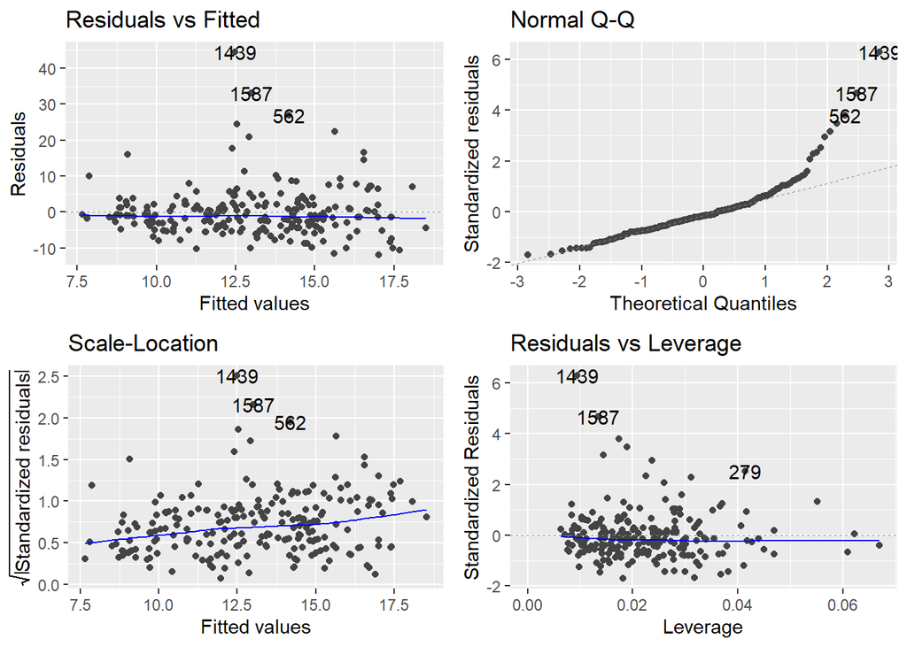

**Summary table for MPG (pre-follow-up)**

|  | MPG (fu) crude | MPG (fu) adj. |
| --- | --- | --- |
| UpsizingYes | 0.2 [-1.3, 1.8] | -2.5 *[-4.8, -0.2] |
| Pre MPG |  | 0.0 [0.0, 0.1] |
| Time, days (fu-sx) |  | 0.0 [0.0, 0.0] |
| Prosthesis_Anat_Size |  | -1.1 ***[-1.6, -0.7] |
| Num.Obs. | 439 | 223 |

# EF (pre/follow-up)

## Crude

**EF follow-up linear model**

| **Characteristic** | **Beta**<sup>1</sup> | **SE**<sup>2</sup> | **95% CI**<sup>2</sup> | **p-value** |
| --- | --- | --- | --- | --- |
| (Intercept) | 57*** | 0.830 | 55, 58 | <0.001 |
| Upsizing |  |  |  |  |
| No | — | — | — |  |
| Yes | 1.1 | 0.999 | -0.84, 3.1 | 0.3 |

R² = 0.002; Adjusted R² = 0.000; Sigma = 11.2; Statistic = 1.25; p-value = 0.3; df = 1; Log-likelihood = -2,263; AIC = 4,532; BIC = 4,545; Deviance = 74,126; Residual df = 588; No. Obs. = 590  
<sup>1</sup> *p<0.05; **p<0.01; ***p<0.001  
<sup>2</sup> SE = Standard Error, CI = Confidence Interval

## Adjusted

| **Characteristic** | **Beta**<sup>1</sup> | **SE**<sup>2</sup> | **95% CI**<sup>2</sup> | **p-value** |
| --- | --- | --- | --- | --- |
| (Intercept) | 29*** | 7.56 | 14, 44 | <0.001 |
| Pre_LVEF | 0.34*** | 0.035 | 0.28, 0.41 | <0.001 |
| Upsizing |  |  |  |  |
| No | — | — | — |  |
| Yes | 1.4 | 1.18 | -0.91, 3.7 | 0.2 |
| Time, days (fu-sx) | 0.00 | 0.001 | 0.00, 0.00 | 0.3 |
| Prosthesis_Anat_Size | 0.26 | 0.259 | -0.25, 0.77 | 0.3 |

R² = 0.182; Adjusted R² = 0.175; Sigma = 10.6; Statistic = 25.9; p-value = <0.001; df = 4; Log-likelihood = -1,780; AIC = 3,572; BIC = 3,597; Deviance = 52,848; Residual df = 466; No. Obs. = 471  
<sup>1</sup> *p<0.05; **p<0.01; ***p<0.001  
<sup>2</sup> SE = Standard Error, CI = Confidence Interval

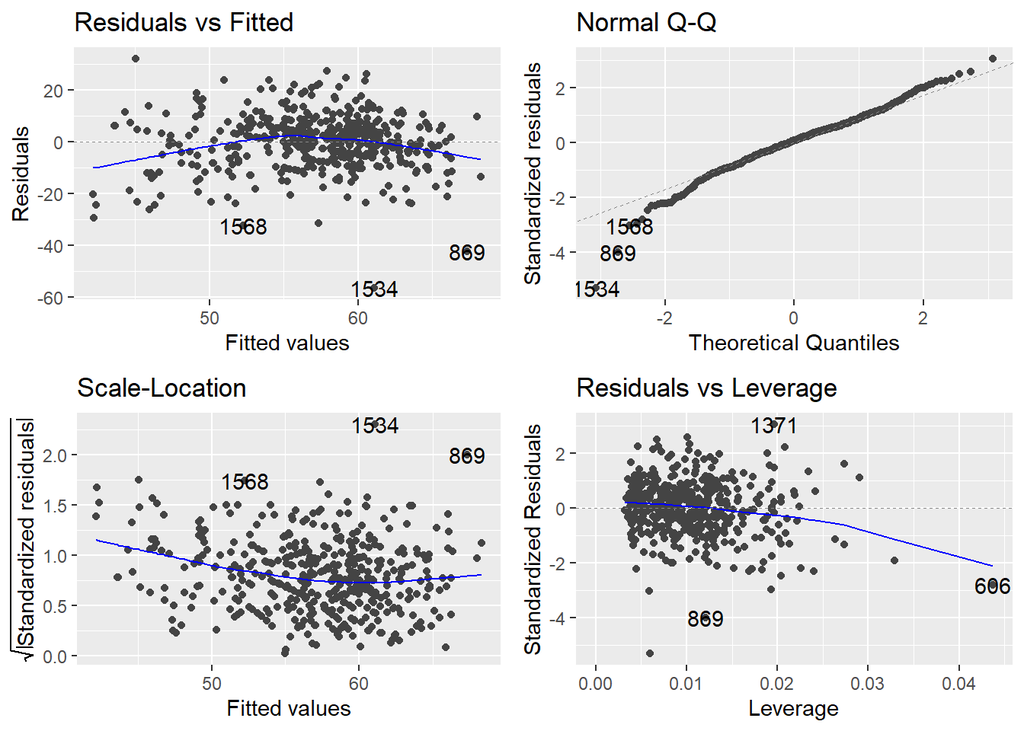

**Summary table for EF (pre-follow-up)**

|  | EF (fu) crude | EF (fu) adj. |
| --- | --- | --- |
| UpsizingYes | 1.1 [-0.8, 3.1] | 1.4 [-0.9, 3.7] |
| Pre_LVEF |  | 0.3 ***[0.3, 0.4] |
| Time, days (fu-sx) |  | 0.0 [0.0, 0.0] |
| Prosthesis_Anat_Size |  | 0.3 [-0.2, 0.8] |
| Num.Obs. | 590 | 471 |